# Predicting Customer Churn

Carson Harris

2025-05-01

# 1 Problem Formulation & Data Understanding

## 1.1 Business Context

*A major telecommunications company is experiencing customer churn, where some subscribers are choosing to cancel their service. This kind of attrition can be expensive because it generally cost more to acquire new customers than to retain existing ones. Churn can be caused by a number of factors including dissatisfaction with the service, increased competition, or unmet expectations. If not addressed, it can lead to a steady loss in revenue and customer base.*

*Predictive modeling offers a way to better understand and respond to this issue. By analyzing customer data such as demographics, billing information, and service usage, machine learning can identify which customers are most likely to leave. This allows the company to take action earlier through targeted offers or support. A well-performing model can help reduce churn and improve the efficiency of retention strategies.*

## 1.2 Dataset Overview

*The Telco Customer Churn dataset, sourced from IBM Sample Data Sets and available on Kaggle, provides information for analyzing customers behavior and predicting churn. It comprises 7,043 customers, each represented by a row with 21 columns capturing their attributes. Key features include whether a customer has churned, the services they have signed up for, account information, and demographic details. Although the specific time of the data collection is not provided, the dataset focuses on customers who left within the last month, allowing for targeted churn analysis. This dataset supports building machine learning models to identify at-risk customers and develop more targeted retention strategies.*

# 2 Data Cleaning & Exploration

## 2.1 Load Packages and Data

```r
#Loading necessary libraries
library(ISLR2)
library(rpart)
library(rpart.plot)
library(caret)
library(pROC)
library(randomForest)
library(gbm)
library(xgboost)
library(tidyverse)
library(dplyr)
library(knitr)

#Loading the data
telco <- read.csv("data/WA_Fn-UseC_-Telco-Customer-Churn.csv")

#Viewing structure
glimpse(telco)
```

```
## Rows: 7,043
## Columns: 21
## $ customerID       <chr> "7590-VHVEG", "5575-GNVDE", "3668-QPYBK", "7795-CFOCW…
## $ gender           <chr> "Female", "Male", "Male", "Male", "Female", "Female",…
## $ SeniorCitizen    <int> 0, 0, 0, 0, 0, 0, 0, 0, 0, 0, 0, 0, 0, 0, 0, 0, 0, 0,…
## $ Partner          <chr> "Yes", "No", "No", "No", "No", "No", "No", "No", "Yes…
## $ Dependents       <chr> "No", "No", "No", "No", "No", "No", "Yes", "No", "No"…
## $ tenure           <int> 1, 34, 2, 45, 2, 8, 22, 10, 28, 62, 13, 16, 58, 49, 2…
## $ PhoneService     <chr> "No", "Yes", "Yes", "No", "Yes", "Yes", "Yes", "No", …
## $ MultipleLines    <chr> "No phone service", "No", "No", "No phone service", "…
## $ InternetService  <chr> "DSL", "DSL", "DSL", "DSL", "Fiber optic", "Fiber opt…
## $ OnlineSecurity   <chr> "No", "Yes", "Yes", "Yes", "No", "No", "No", "Yes", "…
## $ OnlineBackup     <chr> "Yes", "No", "Yes", "No", "No", "No", "Yes", "No", "N…
## $ DeviceProtection <chr> "No", "Yes", "No", "Yes", "No", "Yes", "No", "No", "Y…
## $ TechSupport      <chr> "No", "No", "No", "Yes", "No", "No", "No", "No", "Yes…
## $ StreamingTV      <chr> "No", "No", "No", "No", "No", "Yes", "Yes", "No", "Ye…
## $ StreamingMovies  <chr> "No", "No", "No", "No", "No", "Yes", "No", "No", "Yes…
## $ Contract         <chr> "Month-to-month", "One year", "Month-to-month", "One …
## $ PaperlessBilling <chr> "Yes", "No", "Yes", "No", "Yes", "Yes", "Yes", "No", …
## $ PaymentMethod    <chr> "Electronic check", "Mailed check", "Mailed check", "…
## $ MonthlyCharges   <dbl> 29.85, 56.95, 53.85, 42.30, 70.70, 99.65, 89.10, 29.7…
## $ TotalCharges     <dbl> 29.85, 1889.50, 108.15, 1840.75, 151.65, 820.50, 1949…
## $ Churn            <chr> "No", "No", "Yes", "No", "Yes", "Yes", "No", "No", "Y…
```

## 2.2 Data Quality Check

```r
#Checking for missing values, data types
colSums(is.na(telco))
```

```
##       customerID           gender    SeniorCitizen          Partner
##                0                0                0                0
##       Dependents           tenure     PhoneService    MultipleLines
##                0                0                0                0
##  InternetService   OnlineSecurity     OnlineBackup DeviceProtection
##                0                0                0                0
##      TechSupport      StreamingTV  StreamingMovies         Contract
##                0                0                0                0
## PaperlessBilling    PaymentMethod   MonthlyCharges     TotalCharges
##                0                0                0               11
##            Churn
##                0
```

## 2.3 Data Preprocessing

*During data preprocessing, the primary focus was on handling missing values and preparing the target variable for analysis. Missing values in the TotalCharges column were estimated by multiplying MonthlyCharges by tenure, based on the assumption that they corresponded to newly acquired customers who had not yet been billed. The Churn column was converted from categorical (“Yes”/“No”) to binary format (1/0) to facilitate visualization and modeling. No additional encoding or feature transformation was applied at this stage to retain the dataset’s original structure for exploratory analysis.*

```r
#Cleaning missing or erroneous data
telcoCleanEDA <- telco %>%
  mutate(
    TotalCharges = if_else(is.na(TotalCharges), MonthlyCharges * tenure, TotalCharges),
    Churn = if_else(Churn == "Yes", 1, 0)  # encode target so you can plot
  )
```

## 2.4 Exploratory Data Analysis

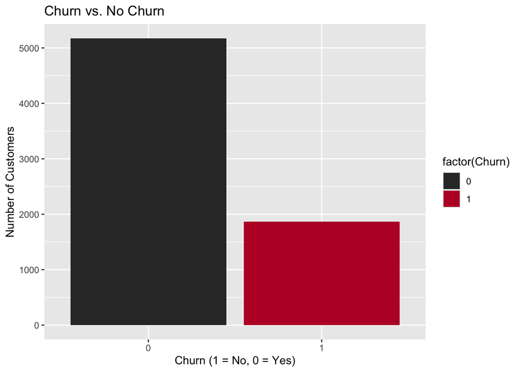

```r
#Visualizing distributions and relationships
dawg_red <- "#BA0C2F"
dark_gray <- "#333333"

telcoCleanEDA %>%
  ggplot(aes(x = factor(Churn), fill = factor(Churn))) +
  scale_fill_manual(values = c("0" = dark_gray, "1" = dawg_red)) +
  geom_bar() +
  labs(title = "Churn vs. No Churn", x = "Churn (1 = No, 0 = Yes)", y = "Number of Customers")
```

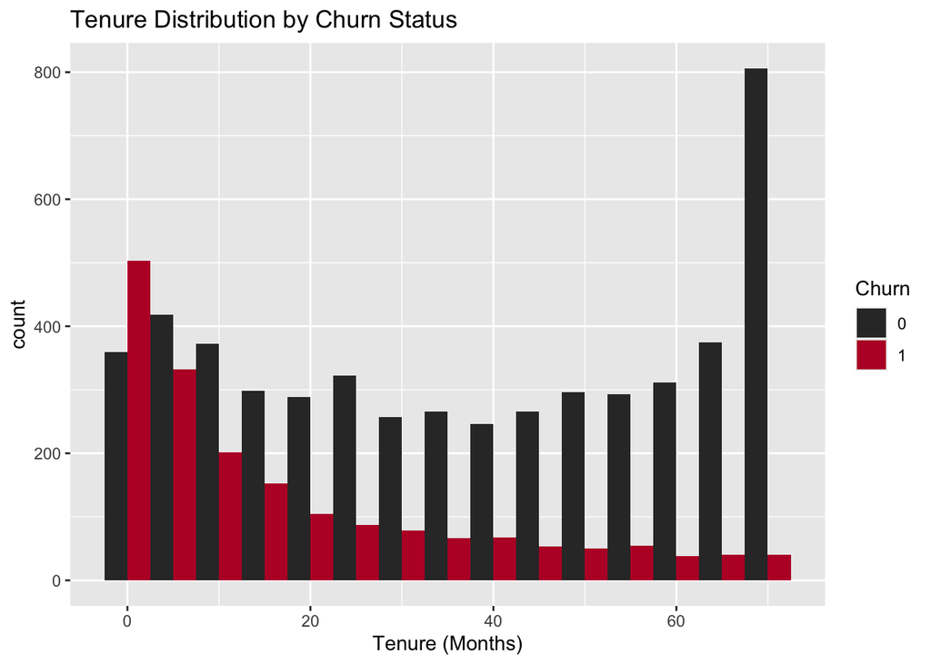

```r
telcoCleanEDA %>%
  ggplot(aes(x = tenure, fill = factor(Churn))) +
  geom_histogram(binwidth = 5, position = "dodge") +
  scale_fill_manual(values = c("0" = dark_gray, "1" = dawg_red)) +
  labs(title = "Tenure Distribution by Churn Status", x = "Tenure (Months)", fill = "Churn")
```

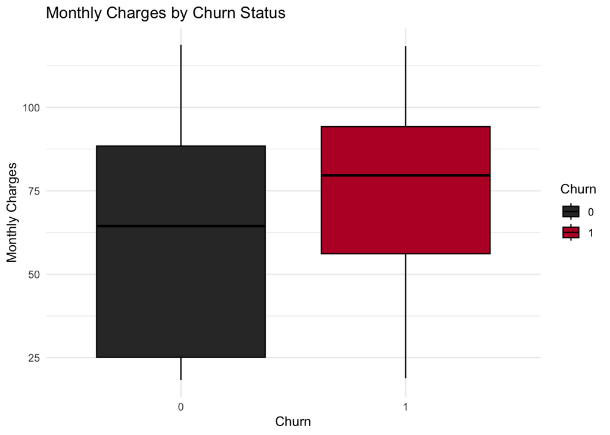

```r
telcoCleanEDA %>%
  ggplot(aes(x = factor(Churn), y = MonthlyCharges, fill = factor(Churn))) +
  geom_boxplot(color = "black",
               aes(group = factor(Churn)),
               outlier.color = "gray",
               outlier.shape = 16,
               outlier.size = 1.5,
               coef = 1.5) +
  scale_fill_manual(values = c("0" = dark_gray, "1" = dawg_red)) +
  labs(
    title = "Monthly Charges by Churn Status",
    x = "Churn",
    y = "Monthly Charges",
    fill = "Churn"
  ) +
  theme_minimal()
```

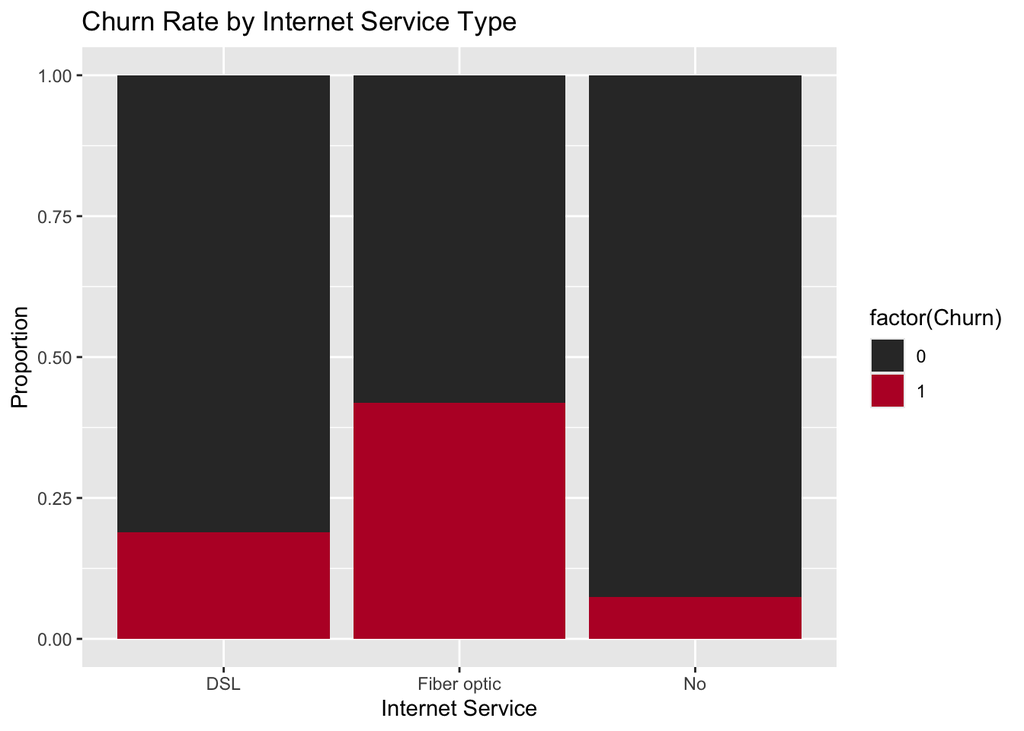

```r
telcoCleanEDA %>%
  ggplot(aes(x = InternetService, fill = factor(Churn))) +
  geom_bar(position = "fill") +
  scale_fill_manual(values = c("0" = dark_gray, "1" = dawg_red)) +
  labs(title = "Churn Rate by Internet Service Type", x = "Internet Service", y = "Proportion")
```

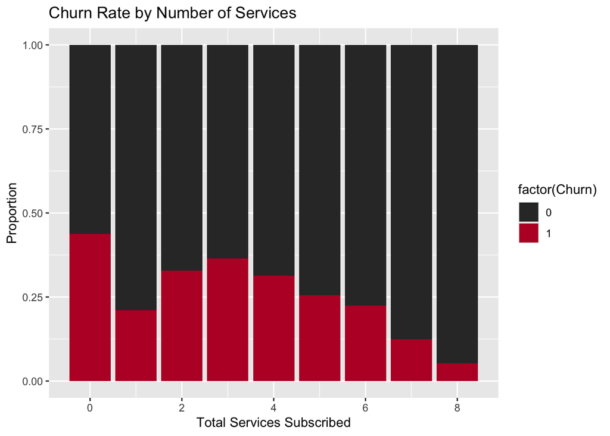

```r
 #Adding TotalServices feature - done here for the visual but done again in feature engineering
telcoCleanEDA %>%
  ggplot(aes(
    x = rowSums(select(., PhoneService, MultipleLines, OnlineSecurity, OnlineBackup,
                       DeviceProtection, TechSupport, StreamingTV, StreamingMovies) == "Yes"),
    fill = factor(Churn)
  )) +
  geom_bar(position = "fill") +
  scale_fill_manual(values = c("0" = dark_gray, "1" = dawg_red)) +
  labs(title = "Churn Rate by Number of Services", x = "Total Services Subscribed", y = "Proportion")
```

*The dataset is imbalanced, with significantly fewer customers churning compared to those who stayed, which is generally a good sign for the company. Churn appears more common among newer customers, especially within the first 24 months of tenure. Customers who churn also tend to have higher monthly charges, and the spread of those charges is more concentrated. Looking at service types, customers with fiber optic internet have the highest churn rate. When analyzing how many services a customer subscribes to, those with no services are the most likely to churn, likely due to low engagement. Churn rates are also somewhat higher among customers with two to four services. These patterns suggest that both service usage and cost play a role in predicting churn behavior.*

# 3 Feature Engineering

## 3.1 New Feature Creation

```r
#Creating new feature - TotalServices
telco <- telco %>%
  mutate(
    TotalServices = rowSums(select(., PhoneService, MultipleLines, OnlineSecurity, OnlineBackup, DeviceProtection, TechSupport, StreamingTV, StreamingMovies) == "Yes")
  )
```

*A new feature was created to provide more insight into customer behavior. TotalServices captures the number of services each customer subscribes to by counting how many service-related fields are marked “Yes” which helps quantify overall customer engagement.*

## 3.2 Feature Encoding

```r
#Encoding features to be binary
cleaningTelco <- telco %>%
  mutate(
    gender = if_else(gender == "Female", 1, 0),
    Partner = if_else(Partner == "Yes", 1, 0),
    Dependents = if_else(Dependents == "Yes", 1, 0),
    PhoneService = if_else(PhoneService == "Yes", 1, 0),
    MultipleLines = if_else(MultipleLines == "Yes", 1, 0),
    dsl = if_else(InternetService == "DSL", 1, 0),
    fiberOptic = if_else(InternetService == "Fiber optic", 1, 0),
    OnlineSecurity = if_else(OnlineSecurity == "Yes", 1, 0),
    OnlineBackup = if_else(OnlineBackup == "Yes", 1, 0),
    DeviceProtection = if_else(DeviceProtection == "Yes", 1, 0),
    TechSupport = if_else(TechSupport == "Yes", 1, 0),
    StreamingTV = if_else(StreamingTV == "Yes", 1, 0),
    StreamingMovies = if_else(StreamingMovies == "Yes", 1, 0),
    OneYearContract = if_else(Contract == "One year", 1, 0),
    TwoYearContract= if_else(Contract == "Two year", 1, 0),
    PaperlessBilling = if_else(PaperlessBilling == "Yes", 1, 0),
    PaymentByMail = if_else(PaymentMethod == "Mailed check", 1, 0),
    PaymentByBankTransfer = if_else(PaymentMethod == "Bank transfer (automatic)", 1, 0),
    PaymentByCreditCard = if_else(PaymentMethod == "Credit card (automatic)", 1, 0),
    TotalCharges = if_else(is.na(TotalCharges), MonthlyCharges * tenure, TotalCharges),
    Churn = factor(Churn, levels = c("No", "Yes"))
  )

#Creating a new DF and selecting only numeric columns for modeling
numericTelco <- cleaningTelco %>%
  select(gender, SeniorCitizen, Partner, Dependents, tenure, TotalServices,
         PhoneService, MultipleLines, dsl, fiberOptic, OnlineSecurity, OnlineBackup,
         DeviceProtection, TechSupport, StreamingTV, StreamingMovies,
         OneYearContract, TwoYearContract, PaperlessBilling,
         PaymentByMail, PaymentByBankTransfer, PaymentByCreditCard,
         MonthlyCharges, TotalCharges, Churn)
```

*All categorical features were encoded using binary dummy variables to prepare the data for modeling. One category from each feature was intentionally left out to serve as the reference group.*

# 4 Model Selection & Training

## 4.1 Model Choice

*Three models were selected to explore different approaches to predicting customer churn. Logistic regression was chosen for its simplicity and interpretability, providing insight into how each feature influence churn probability. A decision tree model was included to capture nonlinear relationships and provide a visual and rule-based structure for decision making. Lastly, a random forest model was used to improve predictive performance through ensemble learning and reduce the risk of overfitting by averaging across multiple decision trees.*

## 4.2 Train-Test Split

```r
#Splitting the data into training and testing
set.seed(123)

split <- sample(c(TRUE, FALSE), nrow(numericTelco), replace = TRUE, prob = c(0.7, 0.3))

train <- numericTelco[split, ]
test <- numericTelco[!split, ]
```

## 4.3 Train Models

```r
#Logistic Regression
log_model <- glm(Churn ~ ., data = train, family = "binomial")

summary(log_model)
```

```
##
## Call:
## glm(formula = Churn ~ ., family = "binomial", data = train)
##
## Coefficients: (1 not defined because of singularities)
##                         Estimate Std. Error z value Pr(>|z|)
## (Intercept)           -0.2886922  0.2378543  -1.214 0.224849
## gender                 0.0530418  0.0772778   0.686 0.492474
## SeniorCitizen          0.1688639  0.1003531   1.683 0.092434 .
## Partner               -0.0175653  0.0925762  -0.190 0.849514
## Dependents            -0.1745825  0.1066686  -1.637 0.101697
## tenure                -0.0579849  0.0073842  -7.853 4.08e-15 ***
## TotalServices          0.5967642  0.3878821   1.539 0.123922
## PhoneService          -0.4576862  0.4186245  -1.093 0.274258
## MultipleLines         -0.1215931  0.2312831  -0.526 0.599074
## dsl                    1.7097921  0.9563020   1.788 0.073789 .
## fiberOptic             3.6820015  1.8905476   1.948 0.051465 .
## OnlineSecurity        -0.7506663  0.2333281  -3.217 0.001294 **
## OnlineBackup          -0.5272657  0.2296885  -2.296 0.021701 *
## DeviceProtection      -0.4388275  0.2345454  -1.871 0.061349 .
## TechSupport           -0.7537686  0.2358311  -3.196 0.001392 **
## StreamingTV            0.1394554  0.1553579   0.898 0.369378
## StreamingMovies               NA         NA      NA       NA
## OneYearContract       -0.6452523  0.1287467  -5.012 5.39e-07 ***
## TwoYearContract       -1.2873676  0.2037370  -6.319 2.64e-10 ***
## PaperlessBilling       0.3795945  0.0889915   4.266 1.99e-05 ***
## PaymentByMail         -0.3053605  0.1148791  -2.658 0.007858 **
## PaymentByBankTransfer -0.3158227  0.1128988  -2.797 0.005152 **
## PaymentByCreditCard   -0.4397803  0.1160864  -3.788 0.000152 ***
## MonthlyCharges        -0.0430084  0.0376820  -1.141 0.253723
## TotalCharges           0.0002896  0.0000838   3.455 0.000549 ***
## ---
## Signif. codes:  0 '***' 0.001 '**' 0.01 '*' 0.05 '.' 0.1 ' ' 1
##
## (Dispersion parameter for binomial family taken to be 1)
##
##     Null deviance: 5747.2  on 4949  degrees of freedom
## Residual deviance: 4103.8  on 4926  degrees of freedom
## AIC: 4151.8
##
## Number of Fisher Scoring iterations: 6
```

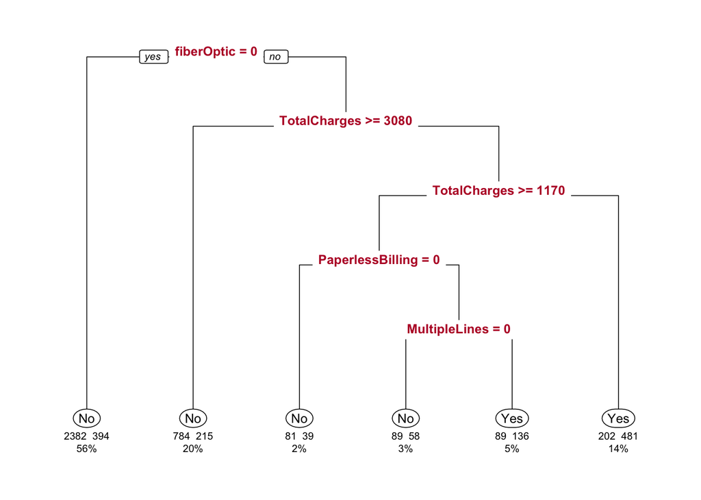

```r
#Decision Tree
tree_model <- rpart(Churn ~ ., data = train, method = "class")

rpart.plot(tree_model,
  type = 0,                     # Separate label boxes
  extra = 101,                  # Show prob + % observations
  box.palette = 0,              # White boxes (no color fill)
  shadow.col = NA,              # Remove the gray shadow
  branch.col = "#000000",       # Black lines
  split.col = "#BA0C2F",        # Dawg Red text for splits
  fallen.leaves = TRUE,         # Layout leaves at bottom
  under = TRUE,                 # Place node info under split
  tweak = 1.1,                  # Slight size increase for splits
  cex = 0.7                     # Shrink all text a bit to avoid overlap
)
```

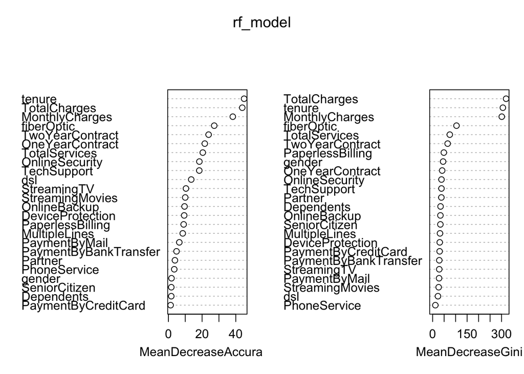

```r
#Random Forest
rf_model <- randomForest(Churn ~ ., data = train, ntree = 500, mtry = 5, importance = TRUE)

varImpPlot(rf_model)
```

## 4.4 Hyperparameter Tuning

```r
#Tuning hyperparameters

train$Churn <- as.factor(train$Churn)

control <- trainControl(method = "cv", number = 5)

tuned_tree <- train(
  Churn ~ .,
  data = train,
  method = "rpart",
  trControl = control,
  tuneLength = 10
)

print(tuned_tree)
```

```
## CART
##
## 4950 samples
##   24 predictor
##    2 classes: 'No', 'Yes'
##
## No pre-processing
## Resampling: Cross-Validated (5 fold)
## Summary of sample sizes: 3959, 3961, 3960, 3959, 3961
## Resampling results across tuning parameters:
##
##   cp           Accuracy   Kappa
##   0.002771479  0.7977748  0.4339898
##   0.003023432  0.7987824  0.4292946
##   0.003401361  0.7935266  0.4123212
##   0.003779289  0.7941333  0.4165577
##   0.004157218  0.7947391  0.4164770
##   0.005794911  0.7945394  0.4133602
##   0.008314437  0.7874685  0.3920733
##   0.017762661  0.7838329  0.3888421
##   0.019652305  0.7842369  0.3894151
##   0.095616024  0.7674805  0.2999399
##
## Accuracy was used to select the optimal model using the largest value.
## The final value used for the model was cp = 0.003023432.
```

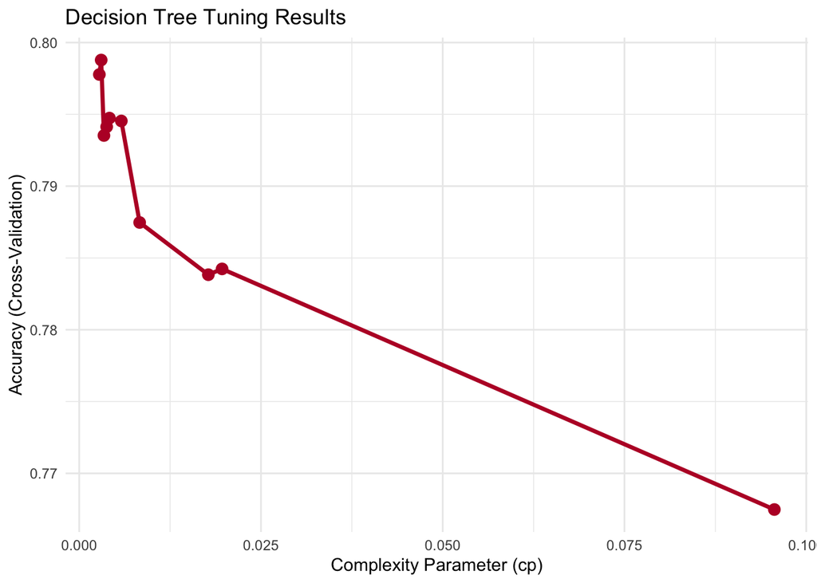

```r
ggplot(tuned_tree$results, aes(x = cp, y = Accuracy)) +
  geom_line(color = "#BA0C2F", size = 1.2) +
  geom_point(color = "#BA0C2F", size = 3) +
  labs(
    x = "Complexity Parameter (cp)",
    y = "Accuracy (Cross-Validation)",
    title = "Decision Tree Tuning Results"
  ) +
  theme_minimal()
```

```r
tuneGrid <- expand.grid(mtry = c(2, 4, 6, 8, 10))

tuned_rf <- train(
  Churn ~ .,
  data = train,
  method = "rf",
  trControl = control,
  tuneGrid = tuneGrid,
  ntree = 300
)

print(tuned_rf)
```

```
## Random Forest
##
## 4950 samples
##   24 predictor
##    2 classes: 'No', 'Yes'
##
## No pre-processing
## Resampling: Cross-Validated (5 fold)
## Summary of sample sizes: 3960, 3961, 3960, 3960, 3959
## Resampling results across tuning parameters:
##
##   mtry  Accuracy   Kappa
##    2    0.7973708  0.4179324
##    4    0.7953530  0.4334551
##    6    0.7907076  0.4207640
##    8    0.7915179  0.4287504
##   10    0.7878767  0.4185318
##
## Accuracy was used to select the optimal model using the largest value.
## The final value used for the model was mtry = 2.
```

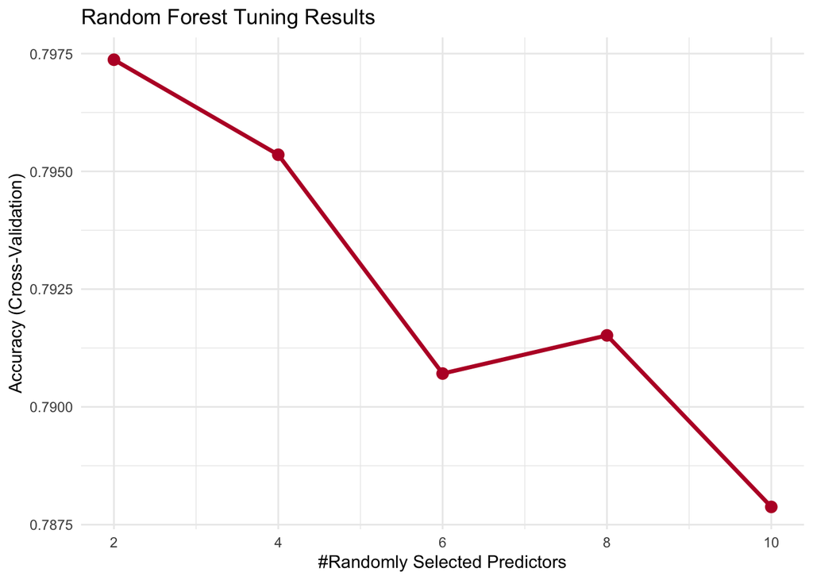

```r
ggplot(tuned_rf$results, aes(x = mtry, y = Accuracy)) +
  geom_line(color = "#BA0C2F", size = 1.2) +    # Dawg Red line
  geom_point(color = "#BA0C2F", size = 3) +     # Dawg Red points
  labs(
    x = "#Randomly Selected Predictors",
    y = "Accuracy (Cross-Validation)",
    title = "Random Forest Tuning Results"
  ) +
  theme_minimal()
```

```r
print(tuned_rf)
```

```
## Random Forest
##
## 4950 samples
##   24 predictor
##    2 classes: 'No', 'Yes'
##
## No pre-processing
## Resampling: Cross-Validated (5 fold)
## Summary of sample sizes: 3960, 3961, 3960, 3960, 3959
## Resampling results across tuning parameters:
##
##   mtry  Accuracy   Kappa
##    2    0.7973708  0.4179324
##    4    0.7953530  0.4334551
##    6    0.7907076  0.4207640
##    8    0.7915179  0.4287504
##   10    0.7878767  0.4185318
##
## Accuracy was used to select the optimal model using the largest value.
## The final value used for the model was mtry = 2.
```

*For better results and to avoid overfitting, I tuned both the decision tree and random forest models using 5-fold cross-validation. For the decision tree, I tested different values of the complexity parameter to find the best balance between accuracy and simplicity. For the random forest, I tuned the mtry value using a custom grid. I looked at how accuracy changed across different values and chose the best setup based on that. This tuning helped make sure both models were well-optimized and ready to perform on new data.*

*For both models, tuning significantly impacted performance. The decision tree had the highest accuracy at a low complexity parameter, balancing model depth with interpretability. The random forest model performed best when mtry was set to 2, indicating that limiting the number of features considered at each split improved generalization and reduced overfitting.*

# 5 Model Evaluation & Comparison

## 5.1 Predictions

```r
# Make predictions on test set

pred_log <- predict(log_model, newdata = test, type = "response")
class_log <- ifelse(pred_log > 0.5, "Yes", "No")
class_log <- factor(class_log, levels = c("No", "Yes"))

pred_tree <- predict(tuned_tree, newdata = test)
prob_tree <- predict(tuned_tree, newdata = test, type = "prob")

pred_rf <- predict(tuned_rf, newdata = test)
prob_rf <- predict(tuned_rf, newdata = test, type = "prob")
```

## 5.2 Confusion Matrices and Metrics

```r
#Evaluating the models with confusion matrix
levels(numericTelco$Churn)
```

```
## [1] "No"  "Yes"
```

```r
confusionMatrix(class_log, test$Churn, positive = "Yes")
```

```
## Confusion Matrix and Statistics
##
##           Reference
## Prediction   No  Yes
##        No  1379  240
##        Yes  168  306
##
##                Accuracy : 0.8051
##                  95% CI : (0.7874, 0.8218)
##     No Information Rate : 0.7391
##     P-Value [Acc > NIR] : 8.605e-13
##
##                   Kappa : 0.472
##
##  Mcnemar's Test P-Value : 0.0004397
##
##             Sensitivity : 0.5604
##             Specificity : 0.8914
##          Pos Pred Value : 0.6456
##          Neg Pred Value : 0.8518
##              Prevalence : 0.2609
##          Detection Rate : 0.1462
##    Detection Prevalence : 0.2265
##       Balanced Accuracy : 0.7259
##
##        'Positive' Class : Yes
##
```

```r
confusionMatrix(pred_tree, as.factor(test$Churn), positive ="Yes")
```

```
## Confusion Matrix and Statistics
##
##           Reference
## Prediction   No  Yes
##        No  1385  288
##        Yes  162  258
##
##                Accuracy : 0.785
##                  95% CI : (0.7668, 0.8024)
##     No Information Rate : 0.7391
##     P-Value [Acc > NIR] : 6.215e-07
##
##                   Kappa : 0.3975
##
##  Mcnemar's Test P-Value : 3.803e-09
##
##             Sensitivity : 0.4725
##             Specificity : 0.8953
##          Pos Pred Value : 0.6143
##          Neg Pred Value : 0.8279
##              Prevalence : 0.2609
##          Detection Rate : 0.1233
##    Detection Prevalence : 0.2007
##       Balanced Accuracy : 0.6839
##
##        'Positive' Class : Yes
##
```

```r
confusionMatrix(pred_rf, as.factor(test$Churn), positive = "Yes")
```

```
## Confusion Matrix and Statistics
##
##           Reference
## Prediction   No  Yes
##        No  1415  288
##        Yes  132  258
##
##                Accuracy : 0.7993
##                  95% CI : (0.7815, 0.8163)
##     No Information Rate : 0.7391
##     P-Value [Acc > NIR] : 6.826e-11
##
##                   Kappa : 0.4266
##
##  Mcnemar's Test P-Value : 3.932e-14
##
##             Sensitivity : 0.4725
##             Specificity : 0.9147
##          Pos Pred Value : 0.6615
##          Neg Pred Value : 0.8309
##              Prevalence : 0.2609
##          Detection Rate : 0.1233
##    Detection Prevalence : 0.1863
##       Balanced Accuracy : 0.6936
##
##        'Positive' Class : Yes
##
```

## 5.3 ROC Curves and AUC

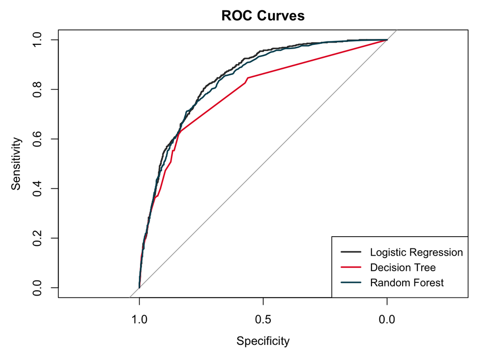

```r
#Plotting ROC curves
dawg_red <- "#E4002B"
uga_blue <- "#004E60"
dark_gray <- "#333333"

roc_log <- roc(test$Churn, pred_log)
roc_tree <- roc(test$Churn, prob_tree[, "Yes"])
roc_rf <- roc(test$Churn, prob_rf[, "Yes"])
#Plotting all curves together
plot(roc_log, col = dark_gray, lwd = 2, main = "ROC Curves")
lines(roc_tree, col = dawg_red, lwd = 2)
lines(roc_rf, col = uga_blue, lwd = 2)

legend("bottomright",
       legend = c("Logistic Regression", "Decision Tree", "Random Forest"),
       col = c(dark_gray, dawg_red, uga_blue),
       lwd = 2,
       cex = 0.9)
```

```r
auc(roc_log)
```

```
## Area under the curve: 0.8451
```

```r
auc(roc_tree)
```

```
## Area under the curve: 0.783
```

```r
auc(roc_rf)
```

```
## Area under the curve: 0.837
```

*Each model performed well, but there were clear differences in accuracy and interpretability. In terms of accuracy, logistic regression led at 80.5%, followed closely by random forest at 79.9%, and then the decision tree at 78.5%. The difference between logistic regression and the random forest was small, only 0.6 percentage points, suggesting both models performed similarly on overall classification.*

*However, comparing ROC curves and AUC highlighted more meaningful differences in each models’ ability to distinguish between those who churned and those who didn’t. Logistic regression achieved the highest AUC at 0.8451, indicating strong overall discriminative ability. The random forest followed closely with an AUC of 0.8367, while the decision tree was lower at 0.783.*

*When it came to identifying actual churners, logistic regression achieved the highest sensitivity (recall) at 56%, meaning it correctly identified more of all customers who actually churned than the tree-based models, which were both around 47%. That’s roughly a 9 percentage point improvement in targeting customers likely to leave. However, when it came to precision, the random forest achieved the highest at 66.2%, meaning when it predicted a customer would churn, it was more correct more often that the other models. In other words, it produced fewer false alarms. Logistic regression followed at 64.6%, and the decision tree at 61.4%.*

*Overall, logistic regression was the strongest performer. While it had slightly lower precision than the random forest, it outperformed the other models in accuracy, discriminative power (AUC), and especially recall. Making it the most reliable option for identifying customers at risk of churning while minimizing false negatives. Although, it relies on the assumption of linear relationships in the data, logistic regression still delivered the most balanced and consistent performance across evaluation metrics.*

# 6 Recommendations & Conclusion

## 6.1 Findings

*Across all three models, several features consistently stood out as key drivers of churn. TotalCharges was among the most important predictors in each model. It was statistically significant in logistic regression, used as a top-level split multiple times in the decision tree, and ranked as the most impactful variable in the random forest based on MeanDecreaseGini. Based on the logistic regression coefficient, the odds of churning increase by approximately 0.029 percent for each additional dollar spent, holding all other variables constant. This translates to a 2.9 percent increase in the odds of churning for every one hundred dollar increase in total charges.*

*Contract type also played a major role. Customers on two year contracts were significantly less likely to churn, as shown by its strong negative coefficient in logistic regression and high importance in the random forest. It had an odds ratio of 0.276, meaning those with two year contracts were about 72.4 percent less likely to churn compared to customers with month to month plans.*

*Features related to service engagement, such as OnlineSecurity, TechSupport, and tenure, were also influential. TechSupport and OnlineSecurity were both negatively associated with reduced churn. Customers who use those services have odds of churning that are roughly 53 percent lower compared to those who do not. In addition, PaperlessBilling and fiber optic internet appeared frequently across models, suggesting that billing preferences and internet type may signal churn risk. These variables provide meaningful insight into which customer segments are most likely to churn and why.*

## 6.2 Business Recommendations

*Promote contract-based plans with incentives. Customers on one and two-year contracts are significantly less likely to churn, likely due to a combination of financial obligation and perceived value. Early termination fees discourage cancellation, but the model also suggests that customers on longer plans may feel more satisfied in their service. Offering incentives to switch from month-to-month to contract-based plans could help reduce churn while reinforcing customer loyalty.*

*Target high-charge customers with retention offers. Customers who churn tend to have higher monthly charges on average. This suggest that high-billing customers may be more price sensitive or dissatisfied with the value. Considering proactive retention strategies like bundling discounts or loyalty rewards for this segment could help reduce churn.*

*Improve and promote use of customer support services. Features like online security and tech support where negatively associated with churn, indicating that customers who engage with these services are more likely to stay. Investing in awareness campaigns and easier access to support could help reduce churn.*

## 6.3 Limitations

*This analysis is based on data from a single point in time, so it does not capture changes in customer behavior or services over time, which could be valuable for predicting churn more accurately.*

*The results show associations, not causation. We cannot definitively say any feature causes retention or churn without further experimental or longitudinal analysis.*

## 6.4 Future Work

*A time series dataset that tracks customer behavior over time would significantly enhance this analysis. It would allow for a more dynamic modeling of churn and help identify early warning signs. These signals could be used to identify customer at risk and trigger timely service interventions aimed at retention.*

*Conducting a randomized experiment or A/B test would also provide stronger evidence of causality by allowing us to evaluate the direct impact of specific features or interventions on churn outcomes.*

# 7 Appendix

Appendix: Variable Definitions

| Variable | Description |
| --- | --- |
| gender | Customer’s gender (Male/Female) |
| SeniorCitizen | Whether the customer is a senior citizen (1 = Yes, 0 = No) |
| Partner | Whether the customer has a partner (1 = Yes, 0 = No) |
| Dependents | Whether the customer has dependents (1 = Yes, 0 = No) |
| tenure | Number of months the customer has stayed with the company |
| TotalServices | Total number of services the customer subscribes to |
| PhoneService | Whether the customer has phone service (1 = Yes, 0 = No) |
| MultipleLines | Whether the customer has multiple lines (1 = Yes, 0 = No) |
| dsl | DSL internet service (1 = Yes, 0 = No) |
| fiberOptic | Fiber optic internet service (1 = Yes, 0 = No) |
| OnlineSecurity | Whether the customer has online security service (1 = Yes, 0 = No) |
| OnlineBackup | Whether the customer has online backup service (1 = Yes, 0 = No) |
| DeviceProtection | Whether the customer has device protection service (1 = Yes, 0 = No) |
| TechSupport | Whether the customer has tech support (1 = Yes, 0 = No) |
| StreamingTV | Whether the customer has streaming TV service (1 = Yes, 0 = No) |
| StreamingMovies | Whether the customer has streaming movies service (1 = Yes, 0 = No) |
| OneYearContract | Customer has a one-year contract (1 = Yes, 0 = No) |
| TwoYearContract | Customer has a two-year contract (1 = Yes, 0 = No) |
| PaperlessBilling | Whether the customer uses paperless billing (1 = Yes, 0 = No) |
| PaymentByMail | Customer pays by mailed check (1 = Yes, 0 = No) |
| PaymentByBankTransfer | Customer pays by bank transfer (1 = Yes, 0 = No) |
| PaymentByCreditCard | Customer pays by credit card (1 = Yes, 0 = No) |
| MonthlyCharges | Amount charged to the customer monthly (numeric) |
| TotalCharges | Total amount charged to the customer to date (numeric) |
| Churn | Whether the customer churned (1 = Yes, 0 = No) |

# 8 Skills Highlighted

- R Programming
- Data Cleaning and Feature Engineering
- Logistic Regression, Decision Tree, Random Forest
- Model Evaluation (Accuracy, Precision, Recall, ROC AUC)
- Business Interpretation of Machine Learning Outputs
- Report Creation in R Markdown